# Spending a Budget, and the Tools

Manuel D. Rossetti, PhD P.E.

## Agenda

- The allocation problem, and marginal analysis by delta value
- Why two echelons break convexity, convexification, and flushout
- Many items under one budget, and the procedure that returns a curve
- The workbook: the depot first, and pricing a repair contract on the sheets
- The software: one class for two models, two searches, and a budget priced instead of enforced

## What Is Being Chosen, and Against What

A stock level at the depot and one at each storeroom, **for every item**. Nine items and four storerooms is forty-five numbers, competing for the same money. Minimize the **total expected backorders at the storerooms**,

$$\mathit{EBO} = \sum_{\text{items}}\;\sum_{j=1}^{J}\bar{B}_j(S_j)
\qquad\text{subject to}\qquad
\sum_{\text{items}}\Big(c_0S_0 + \sum_{j=1}^{J}c_jS_j\Big) \le \text{budget}$$

where $c_j$ and $c_0$ represent the item’s unit cost at storeroom $j$ and at the depot.

**Notice what the objective leaves out**

No crew waits at a depot, so a depot backorder costs nothing directly. It costs by lengthening $\bar{W}$, which inflates every storeroom’s pipeline. Depot stock is valued entirely for what it does elsewhere, which is what makes this one multi-echelon problem rather than five separate ones.

## Marginal Analysis

For each item and location, the **delta value** is what the next unit buys per dollar. Recall that the next unit removes $G^{0}(S)$ backorders:

$$\delta(S) = \frac{\bar{B}(S) - \bar{B}(S+1)}{c} = \frac{G^{0}(S)}{c}$$

Buy repeatedly, each time taking the candidate with the largest delta value, until the budget runs out. The earliest published reference is Gross (1956); Sherbrooke calls it “the increase in system effectiveness per dollar,” and notes that calling it the greedy heuristic is “hardly an improvement.”

It works only if delta values **decline** as you buy. At one location they do: $G^{0}$ is nonincreasing, so $\bar{B}$ is convex, and a sum of convex functions is convex.

Were that not so, a one-step look would undervalue an item whose next two units together are worth more than the first alone, and other items would be bought prematurely.

## Two Echelons Break the Convexity

Fix the depot and vary a storeroom: convex. But moving the depot moves every storeroom’s pipeline at once, and across the best splits there is **no assurance of convexity**.

| Units | $S_0$ | At storerooms | $\mathit{EBO}$ | Reduction |
| --- | --- | --- | --- | --- |
| 10 | 10 | 0 | 18.6080 | 0.9967 |
| 11 | 11 | 0 | 17.6154 | 0.9927 |
| 12 | 12 | 0 | 16.6303 | 0.9850 |
| 13 | 9 | 4 | 15.6433 | 0.9870 |
| 14 | 10 | 4 | 14.6587 | 0.9846 |
| ⋮ |  |  |  |  |
| 19 | 15 | 4 | 9.9647 | 0.8842 |
| 20 | 12 | 8 | 9.1088 | 0.8559 |
| 21 | 13 | 8 | 8.2462 | 0.8627 |

The best split of each total, by VARI-METRIC. Read the Reduction column: where does it **rise**, and which plan is the bad one?

It rises at 13 and at 21. So totals **12** and **20** lie above the line through their neighbors:

$$\frac{17.6154 + 15.6433}{2} = 16.6294 < 16.6303$$

Plan 12 is never worth buying.

## Thirteen Transformers, Six Ways

Each row of the last table is the smallest entry of a comparison like this one.

| $S_0$ | Forward | $\mathit{EBO}$ |
| --- | --- | --- |
| 13 | 0 | 15.6584 |
| 12 | 1 | 15.6519 |
| 11 | 2 | 15.6485 |
| 10 | 3 | 15.6461 |
| 9 | 4 | **15.6433** |
| 8 | 5 | 15.6744 |

*No forward stock.* A storeroom holding nothing owes its whole pipeline, so $\mathit{EBO} = 4(1.9726) + \bar{B}_0(S_0) = 7.8904 + G^{1}(13) = 7.8904 + 7.7680 = 15.6584$.

*Nine at the depot, one at each storeroom.* $\bar{B}_0(9) = 11.7143$ and $\mathit{Var}[B_0] = 20.6612$:

$$\begin{aligned}
\mu_j &= 1.9726 + 0.25(11.7143) = 4.9012\\
\sigma_j^{2} &= 1.9726 + (0.25)(0.75)(11.7143) + (0.25)^{2}(20.6612) = 5.4604\\
p &= 4.9012/5.4604 = 0.8976, \quad r = 42.959, \quad g(0) = p^{r} = 0.0096\\
\bar{B}_j(1) &= \mu_j - G^{0}(0) = 4.9012 - 0.9904 = 3.9108
\end{aligned}$$

Four storerooms owe $4(3.9108) = 15.6433$.

## Convexification, and Flushout

**Convexification.** Strike out 12 and 20. The procedure moves from 11 straight to 13 and from 19 straight to 21, buying two at a time and quoting the average of the two reductions as its delta value.

| Units bought | 10 | 11 | 12 | **13** | … | 19 | **20** | 21 |
| --- | --- | --- | --- | --- | --- | --- | --- | --- |
| Best $S_0$ | 10 | 11 | 12 | **9** |  | 15 | **12** | 13 |

**Flushout.** The best depot stock **falls** as the total rises. Going from twelve transformers to thirteen, the depot drops from twelve to nine and four appear at the storerooms. Sherbrooke’s name: depot stock is flushed out to the bases.

**Why.** A depot unit buys $G^{0}(S_0)/\lambda_0$ off the delay, shared by four storerooms. While the depot is nearly empty that delay is enormous and pooling dominates; once it is comfortable, a unit does more on the shelf a crew can reach.

The model answers the positioning question **as a function of the budget**: not “forward stocked?” but “forward stocked at what total investment?”, and not monotonically.

## Across Items

Items combine by the same rule, with reductions divided by unit cost. The utility also stocks a voltage regulator: $9,500, 12 failures a year per storeroom, a fifth rebuilt locally in 45 days, depot repair 90 days, shipment 10 days.

| Step | Bought | $\delta$ per $1,000 | Spend | $\mathit{EBO}$, transformer | $\mathit{EBO}$, regulator |
| --- | --- | --- | --- | --- | --- |
| 1 | transformer | 0.2632 | $3,800 | 27.6027 | 11.7041 |
| 12 | transformer, two | 0.2595 | $49,400 | 15.6433 | 11.7041 |
| 19 | transformer, two | 0.2261 | $79,800 | 8.2462 | 11.7041 |
| 28 | transformer | 0.1148 | $114,000 | 2.5852 | 11.7041 |
| 29 | regulator | 0.1053 | $123,500 | 2.5852 | 10.7042 |
| 41 | regulator | 0.0734 | $214,700 | 1.3122 | 3.5973 |

**The delta column never rises:** that is what convexification bought. Steps 12 and 19 jump the struck-out totals.

**No regulator until $114,000** has gone into transformers. The transformer fails nearly four times as often and costs less than half as much, so it removes about a quarter of a backorder per thousand dollars against a tenth.

## Three Delta Values, Worked

$$\begin{aligned}
\mathit{EBO} &= 7.8904 + G^{1}(0) = 7.8904 + 20.7123 = 28.6027
&&\text{the transformer with no stock anywhere}\\
\delta_{1} &= \frac{G^{0}(0)}{3{,}800} = \frac{1.0000}{3{,}800} = 0.2632 \text{ per } \$1{,}000
&&\text{step 1: the first unit, at the depot}\\
\delta_{12} &= \frac{17.6154 - 15.6433}{2 \times 3{,}800} = \frac{1.9721}{7{,}600} = 0.2595 \text{ per } \$1{,}000
&&\text{step 12: two units, over total 12}\\
\delta_{29} &= \frac{0.9999}{9{,}500} = 0.1053 \text{ per } \$1{,}000
&&\text{step 29: the regulator's first unit}
\end{aligned}$$

A jump over a struck-out total buys two units, so its reduction is the fall across both and its cost is two units. That average is what keeps the delta column from rising.

## The Procedure Returns a Curve

```
allocate(budget, items):
  for each item:
    // Step 1, the two-echelon curve
    for S_0 = 0, 1, 2, ...:
      Wbar <- depot delay at S_0      // VARI-METRIC
      for n = 0, 1, 2, ... at storerooms:
        spread n by marginal analysis
        EBO[S_0][n] <- storeroom backorders
    // Step 2, best split per total; convexify
    curve[T] <- min over S_0 + n = T
    drop every T whose reduction is
         exceeded by the next one
    // Step 3, delta values on what survives
  // Step 4, merge the items by largest delta
  while the next buy fits the budget:
    buy the item whose next delta is largest
  return stock levels, and EBO against cost
```

Every step of the merge is an efficient plan for the money spent so far, so the output is the **whole schedule** of backorders against budget.

That is more useful than one plan: a utility can ask whether the step from $114,000 to $123,500 is worth it, which it can answer and the model cannot.

The last buy can overshoot badly if it is an expensive unit. Take the levels reached as **minimums** and rerun.

## The Workbook: the Depot First

`Chapter9Models.xlsx`, ordered the way the chapter solves: `Depot`, then `Storeroom`, then `Allocate`, plus `Ledger`.

**Depot.** One row per unit of pipeline. $G$ from `POISSON.DIST`, $G^{0}$ its complement, $G^{1}$ the recursion filled down. The fourth column is the one VARI-METRIC adds, the second-moment recursion:

```
E21:  =$B$13+$B$13^2
E22:  =E21-D22-D21
```

The stock level is the only decision typed; $\bar{B}_0$ and $\mathit{Var}[B_0]$ read out by `INDEX`.

**Storeroom.** METRIC closes in one cell, since $G^{1}(s) = \mu(1 - F(s-1)) - s(1 - F(s))$ for a Poisson.

VARI-METRIC does not: the fitted $r = 14.3674$ is not an integer and `NEGBINOM.DIST` **truncates** it, quietly computing the wrong distribution. The sheet builds the mass function by its own recursion,

$$g(0) = p^{r}, \qquad g(x) = g(x-1)\,\frac{r+x-1}{x}(1-p)$$

and one cell holds the on-hand identity, which must read zero.

## The Two Models on One Screen

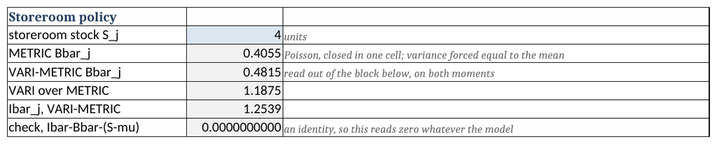

The `Storeroom` sheet at the chapter’s plan. Notice the ratio of the two backorder figures, 1.1875: VARI-METRIC reports about nineteen percent more on a plan neither model changed.

Notice the residual at the bottom, which reads zero to ten places. That is the reason to trust the nineteen percent: both models satisfy the same identity, so the difference is in the tail, not in the bookkeeping.

## Allocate and Ledger Sheets

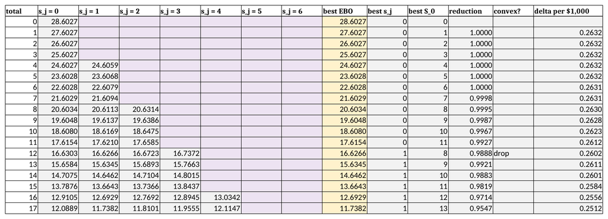

**Allocate** lays the search flat: one row per total, one column per split. Read the best $S_0$ column down: it climbs to 11 and drops to 8 at total 12, one unit earlier than the VARI-METRIC table, because the sheet runs METRIC.

The convexity flag looks **forward**:

```
M9: =IF(OR(L9="",L10=""),"",
       IF(L10>L9,"drop",""))
```

**Ledger** dots the level column with a weeks-held column, `=SUMPRODUCT(G5:G23,K5:K23)`, so the wrong average is harder to write.

## Pricing a Repair Contract

The depot shop offers, for a fee, to hold transformer turnaround at 45 days instead of 60. The plan is $S_0 = 16$, $S_j = 4$. On `Depot`, type **45** into `B10`, one number on a sheet that never mentions a storeroom. What happens to the storerooms?

| Cell | What it is | Before | After |
| --- | --- | --- | --- |
| `Depot!B13` | $\mu_0$ | 20.7123 | 15.5342 |
| `Depot!B17` | $\bar{B}_0$ | 5.0201 | 1.3500 |
| `Depot!B20` | $\bar{W}$, days | 14.54 | 3.91 |
| `Storeroom!B22` | $\mu_j$ | 3.2276 | 2.3101 |
| `Storeroom!B34` | $\bar{B}_j$ | 0.4815 | 0.1523 |

Across four storerooms, 1.9259 falls to 0.6091: **68%**. A quarter cut in repair time removed two thirds of the waiting, because the delay divides a backorder level that is itself falling steeply.

*The check.* $1.3500/126 = 0.010714$ years, which is 3.91 days, as `B20` reports.

## What the Same Improvement Costs in Stock

Put 60 back, and buy the reduction instead by raising the depot stock:

| `Depot!B16` | 16 | 18 | 20 | 21 | 22 |
| --- | --- | --- | --- | --- | --- |
| `Depot!B20`, days | 14.54 | 9.98 | 6.30 | 4.84 | 3.64 |
| `Storeroom!B34` | 0.4815 | 0.3280 | 0.2199 | 0.1807 | **0.1501** |

**Six more depot transformers do what the contract does.** At the carrying charge of 0.25 a year,

$$6 \times 0.25 \times \$3{,}800 = \$5{,}700 \text{ a year}$$

so the contract is worth **up to $5,700 a year**. A shop asking $4,000 should be taken; one asking $9,000 should be refused and the money spent on stock.

**Where should the six go?**

`Allocate` at a total of 38 says 18 at the depot and 5 per storeroom, not 22 and 4. It runs METRIC; judged by VARI-METRIC, 18-and-5 gives 0.6157 against 0.6005, about 2.5% worse, in the direction METRIC’s error predicts.

## Designing the Software: the Nouns

Underline the nouns in the requirements and four survive: a **storeroom**, a **depot item** (one item’s depot stock and the storerooms it supplies), a **model** (a set of depot items), and a **search**, the only thing that chooses.

Three candidates fail, instructively:

- **A depot class.** Everything asked of the depot is a property of a distribution. Its stock and its storerooms travel together, so they are one object.
- **METRIC and VARI-METRIC as two classes.** They agree on every mean, and two classes would let them drift apart where the chapter says they cannot.
- **A pipeline distribution of our own.** The library already has one.

```kotlin
leadTimeDemand = if (depot.forcePoissonAtBases) {
    Poisson(expectedNumInResupply)
} else {
    fitTwoMoments(expectedNumInResupply, varianceNumInResupply)
}
```

Notice that the two models are a **flag**, not a type: one object computes the mean, so they cannot disagree about it.

## What the Library Supplies

**The loss functions.** Every location asks its distribution for `firstOrderLossFunction`, so the single-location measures are written once and answered by whichever family the fit chose.

**The second moment, in closed form.** A worksheet climbs the recursion because it has rows and no second order loss function. A program has the loss function:

$$E[B^{2}(s)] = 2\,G^{2}(s) + G^{1}(s)$$

**A negative binomial with a fractional $r$.** The library takes $r = 14.3674$ as a real number, so the fit is a constructor call.

```kotlin
val c = variance / mean
return when {
    c > 1.0 + RATIO_TOLERANCE  -> negativeBinomialOn(mean, variance)
    c >= 1.0 - RATIO_TOLERANCE -> Poisson(mean)
    else -> { val scale = variance / mean; Gamma(mean / scale, scale) }
}
```

`RATIO_TOLERANCE` is $10^{-9}$: rounding, not a model. The third branch exists because nobody has proved the variance always exceeds the mean.

## Two Searches, Only One of Them Greedy

**The inner search is greedy and exact.** At a fixed depot stock the storerooms are convex, so handing out units one at a time to whichever gains most cannot be improved on.

**The outer step is a minimum,** the best depot level per total, and that is where convexity is lost.

**Convexification** is a lower convex hull, reached by jumping to whichever later total gives the steepest descent:

```kotlin
var slopeMax = 0.0
for (c in kIndex + 1 until maxRows) {
    val s = slope(kIndex, c)
    if (s >= slopeMax) { slopeMax = s; kLast = c }
}
```

The totals it skips are the ones struck out by hand, and the delta value is computed across the jump.

## Pricing the Budget Instead of Enforcing It

Let $\theta$ represent a charge per dollar held, and minimize

$$w(\theta) = \sum_j \bar{B}_j(S_j) + \theta\Big(c_0S_0 + \sum_j c_jS_j\Big)$$

At a fixed $\theta$ the storerooms no longer compete, and each solves a newsvendor: buy while the chance of needing the next unit exceeds its price,

$$S_j = \min\left\{S : G(S) \ge 1 - \theta c_j\right\}$$

The depot still needs a search, because moving it moves every storeroom.

**The multiplier’s scale is set by the unit cost**

A storeroom stocks nothing once $\theta \ge 1/c_j$, so the useful range is $(0, 1/c_j)$: for a $3,800 transformer, $2.6 \times 10^{-4}$. Search far above it and the algorithm reports, correctly and uselessly, that no root exists.

## Three Searches, Two to One

Both items, a budget of $250,000:

| Search | Spend | Storeroom backorders | Depot, transformer | Inside budget |
| --- | --- | --- | --- | --- |
| Marginal analysis | $247,000 | 2.8792 | 19 | yes |
| Lagrangian, bisection | $247,000 | 2.8792 | 19 | yes |
| Lagrangian, enumeration | $250,800 | 2.6840 | 20 | **no, by $800** |

Stock levels are integers, so cost is a step function of $\theta$: at $5.1356 \times 10^{-5}$ the plan costs $250,800, at $5.1361 \times 10^{-5}$ it costs $247,000. No multiplier spends exactly $250,000, so a search must choose a side.

**Bisection** returns the side that satisfies the constraint. **Enumeration** keeps the smallest absolute gap, and $800 over is closer than $3,000 under.

A planner who must not overspend wants bisection or marginal analysis. One asking what the budget nearly buys learns from the enumeration that $800 more removes another 0.2 backorders. Never read the enumeration’s answer as respecting the budget.

## Running the Chapter’s Examples

```kotlin
val item = VMItem(1, 16, 3800.0, days(60.0))
repeat(4) { item.addBaseItem(45.0, days(30.0), 0.3, days(10.0), 4, 3800.0) }
```

```
  METRIC       mu_j   3.2276  var   3.2276  Bbar_j   0.4055  Ibar_j   1.1778  system   1.6218
  VARI-METRIC  mu_j   3.2276  var   3.9527  Bbar_j   0.4815  Ibar_j   1.2539  system   1.9259
```

```
  total        EBO    S_0  reduction    kept?
     11    17.6154     11     0.9927
     12    16.6303     12     0.9850  dropped
     13    15.6433      9     0.9870
     ...
     20     9.1088     12     0.8559  dropped
     21     8.2462     13     0.8627
```

The network is built depot first, with times in days at the call site so the conversion is visible. Notice that `mu_j` agrees to four decimals and `var` does not: no mean changes, enforced because one object produced both. The depot column falls from 12 to 9 at total 13 and from 15 to 12 at total 20: flushout and non-convexity are the same event seen from two columns.

## What We Did Today, and in This Chapter

**Marginal analysis buys by delta value,** $G^{0}(S)/c$, and needs convexity.

**Two echelons break it.** Convexification strikes out totals 12 and 20, and the depot’s stock falls as the budget rises: flushout, the positioning answer as a function of money.

**Across items, the transformer is bought first** for $114,000, on arithmetic, not unit price.

**The sheets price a contract:** six depot units, $5,700 a year, is what a 45-day turnaround is worth.

**The software keeps one class for two models** and offers searches that differ in which side of the budget they land.

**The chapter in one line.** The depot’s wait couples the levels; Palm, Little and a second moment compute it; marginal analysis spends against it.

## For Next Time

**Read before next session:** the opening of *Multi-Echelon Systems with Batch Ordering*, *What Batching Changes* and *The Item and the Network*.

Today’s material was *Spending a Budget Across Items*, *Building These Models in a Worksheet* and *Designing the Software*.

Next session:

- What changes when a location orders in batches instead of one for one
- A hub that batches, and why the stream it sends up is no longer Poisson

Every simplification of this chapter rested on $Q = 1$. Next chapter gives it up.

⌂ Index